# Kuliah 2

# Metode Hildreth-Lu

```r
hildreth.lu.func <- function(r, model1){
  x <- model.matrix(model1)[,-1]
  y <- model.response(model.frame(model1))
  n <- length(y)
  t <- 2:n
  y <- y[t] - r*y[t-1]
  x <- x[t] - r*x[t-1]
  return(lm(y~x))
}
```

```r
r <- seq(0.1, 0.9, by = 0.1)
tab <- data.frame(rho = r, SSE = sapply(r, function(i) deviance(hildreth.lu.func(i, model1))))
tab[order(tab$SSE), ]
```

```
##   rho      SSE
## 9 0.9 1.455306
## 8 0.8 1.634834
## 7 0.7 1.956630
## 6 0.6 2.450989
## 5 0.5 3.132634
## 4 0.4 4.007525
## 3 0.3 5.078402
## 2 0.2 6.346684
## 1 0.1 7.813168
```

```r
rOpt <- seq(0.1, 0.99, by = 0.001)   # dilebarin sampai 0.99
tabOpt <- data.frame(rho = rOpt, SSE = sapply(rOpt, function(i) deviance(hildreth.lu.func(i, model1))))
best <- tabOpt[which.min(tabOpt$SSE), ]
best
```

```
##       rho      SSE
## 827 0.926 1.439542
```

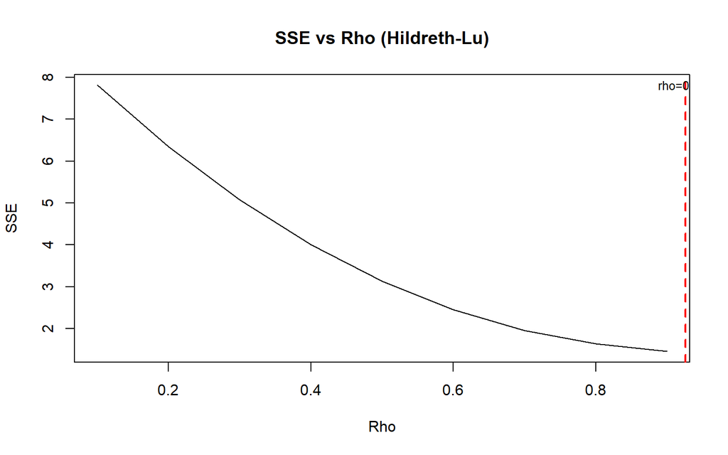

```r
plot(tab$SSE ~ tab$rho, type = "l", xlab = "Rho", ylab = "SSE",
     main = "SSE vs Rho (Hildreth-Lu)")
abline(v = best$rho, lty = 2, col = "red", lwd = 2)
text(x = best$rho, y = max(tab$SSE), labels = paste0("rho=", best$rho), cex = 0.8)
```

Hasilnya diperoleh rho optimum sebesar 0,926 dengan SSE terkecil sebesar 1,439542, yang konsisten dengan hasil metode Cochrane-Orcutt (rho = 0,9265).

```r
model_HL <- hildreth.lu.func(best$rho, model1)
summary(model_HL)
```

```
##
## Call:
## lm(formula = y ~ x)
##
## Residuals:
##      Min       1Q   Median       3Q      Max
## -0.47099 -0.13394  0.00361  0.10764  0.51889
##
## Coefficients:
##             Estimate Std. Error t value Pr(>|t|)
## (Intercept)  0.92469    0.13512   6.844 4.59e-08 ***
## x            0.38851    0.08891   4.370 9.69e-05 ***
## ---
## Signif. codes:  0 '***' 0.001 '**' 0.01 '*' 0.05 '.' 0.1 ' ' 1
##
## Residual standard error: 0.1972 on 37 degrees of freedom
## Multiple R-squared:  0.3404, Adjusted R-squared:  0.3226
## F-statistic: 19.09 on 1 and 37 DF,  p-value: 9.692e-05
```

```r
# pemeriksaan kembali
dwtest(model_HL)
```

```
##
##  Durbin-Watson test
##
## data:  model_HL
## DW = 1.9498, p-value = 0.4105
## alternative hypothesis: true autocorrelation is greater than 0
```

Uji Durbin-Watson pada model hasil transformasi menghasilkan p-value = 0,4105> 0,05, maka H0 tidak ditolak. Artinya, autokorelasi pada sisaan juga sudah teratasi dengan metode ini. Kedua metode penanganan autokorelasi memberikan nilai rho yang hampir sama, dapat disimpulkan bahwa hasil estimasi rho ini robust/dapat diandalkan.

# Perbandingan Akurasi

```r
sseModelawal <- anova(model1)$`Sum Sq`[-1]
sseModelCO   <- anova(model_CO)$`Sum Sq`[-1]
sseModelHL   <- anova(model_HL)$`Sum Sq`[-1]
```

```r
n <- nrow(dt1)
mseModelawal <- sseModelawal / n
mseModelCO   <- sseModelCO / n
mseModelHL   <- sseModelHL / n
```

```r
akurasi <- matrix(c(sseModelawal, sseModelCO, sseModelHL,
                     mseModelawal, mseModelCO, mseModelHL),
                   nrow = 2, ncol = 3, byrow = TRUE)
colnames(akurasi) <- c("Model Awal", "Cochrane-Orcutt", "Hildreth-Lu")
row.names(akurasi) <- c("SSE", "MSE")
akurasi
```

```
##     Model Awal Cochrane-Orcutt Hildreth-Lu
## SSE 10.4633438      1.43953506  1.43954191
## MSE  0.2615836      0.03598838  0.03598855
```

Berdasarkan tabel perbandingan akurasi, model Cochrane-Orcutt dan Hildreth-Lu memberikan hasil yang hampir identik dan keduanya jauh lebih baik dibanding model awal. Penurunan SSE dari 10,4633 menjadi 1,4395 menunjukkan bahwa penanganan autokorelasi berhasil mengurangi kesalahan prediksi model secara signifikan. Secara keseluruhan, **kedua metode penanganan autokorelasi (Cochrane-Orcutt dan Hildreth-Lu) berhasil memperbaiki model** dengan menurunkan SSE dibanding model awal, sekaligus menghilangkan autokorelasi pada sisaan.